# R package `rrtable`

Reproducible Research with a Table of R codes

Keon-Woong Moon

2018-04-15

```r
require(moonBook)
require(ztable)
require(rrtable)
require(ggplot2)
```

### Introduction

If you are a data scientist or researcher, you will certainly be interested in reproducible research. R package `rrtable` makes it possible to make reports with HTML, LaTex, MS word or MS Powerpoint formats from a table of R codes.

### Package Installation

You can install R package `rrtable` with the following command.

```r
if(!require(devtools)){ install.packages("devtools") }
devtools::install_github("cardiomoon/rrtable")
```

### Package Loading

You can load the `rrtable` package with the following R command.

```r
require(rrtable)
```

### Sample Data

Sample data sampleData3 is included in rrtable package. You can see the sampleData3 by folllowing R command.

```r
str(sampleData3)
```

```
'data.frame':   15 obs. of  5 variables:
 $ type  : chr  "title" "subtitle" "author" "text" ...
 $ title : chr  "" "" "" "Introduction" ...
 $ text  : chr  "R package `rrtable`" "Reproducible Research with a Table of R codes" "Keon-Woong Moon" "If you are a data scientist or researcher, you will certainly be interested in reproducible research. R package"| __truncated__ ...
 $ code  : chr  "" "" "" "" ...
 $ option: chr  "" "" "" "" ...
```

### Paragraph

You can make a paragraph with this data

```r
df2flextable2( sampleData3 ,vanilla= FALSE )
```

| type | title | text | code | option |
| --- | --- | --- | --- | --- |
| title |  | R package `rrtable` |  |  |
| subtitle |  | Reproducible Research with a Table of R codes |  |  |
| author |  | Keon-Woong Moon |  |  |
| text | Introduction | If you are a data scientist or researcher, you will certainly be interested in reproducible research. R package `rrtable` makes it possible to make reports with HTML, LaTex, MS word or MS Powerpoint f… |  |  |
| header2 | Package Installation | You can install R package `rrtable` with the following command. | if(!require(devtools)){ install.packages("devtools") } devtools::install_github("cardiomoon/rrtable") | echo=TRUE, eval=FALSE |
| header2 | Package Loading | You can load the `rrtable` package with the following R command. | require(rrtable) | echo=TRUE |
| header2 | Sample Data | Sample data sampleData3 is included in rrtable package. You can see the sampleData3 by folllowing R command. | str(sampleData3) | echo=TRUE, eval=TRUE |
| Data | Paragraph | You can make a paragraph with this data | sampleData3 | landscape=TRUE |
| mytable | mytable object | You can add mytable object with the following R code. | mytable(Dx~.,data=acs) |  |
| plot | Plot | You can insert a plot into your document. | plot(iris) |  |
| ggplot | ggplot | You can insert a ggplot into a document | ggplot(iris,aes(x=Sepal.Length,y=Sepal.Width,color=Species))+ geom_point() |  |
| Rcode | R code | You can insert the result of R code. For example, you can insert the result of regression analysis. | fit=lm(mpg~wt*hp,data=mtcars) summary(fit) |  |
| 2ggplots | Two ggplots | You can insert two parallel ggplots with the following code. | ggplot(iris,aes(Sepal.Length,Sepal.Width))+geom_point() ggplot(iris,aes(Sepal.Length,Sepal.Width,colour=Species))+ geom_point()+guides(colour=FALSE) |  |
| 2plots | Two plots | You can insert two parallel plots with the following code. | hist(rnorm(1000)) plot(1:10) |  |
| header2 | HTML Report | You can get report with HTML format(this file) by following R command. | data2HTML(sampleData3) | echo=TRUE, eval=FALSE |

### mytable object

You can add mytable object with the following R code.

```r
mytable2flextable( mytable(Dx~.,data=acs) ,vanilla= FALSE )
```

[output not shown]

### Plot

You can insert a plot into your document.

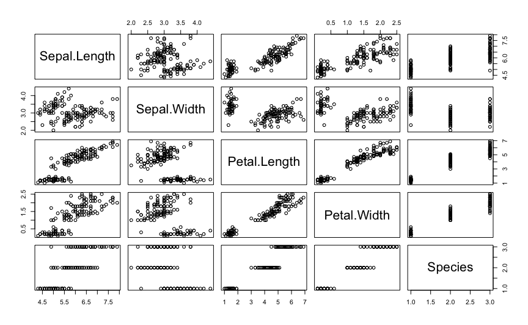

```r
plot(iris)
```

### ggplot

You can insert a ggplot into a document

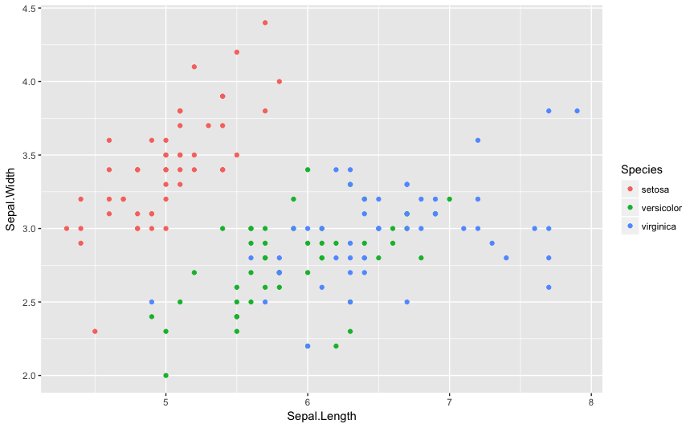

```r
ggplot(iris,aes(x=Sepal.Length,y=Sepal.Width,color=Species))+ geom_point()
```

### R code

You can insert the result of R code. For example, you can insert the result of regression analysis.

```r
fit=lm(mpg~wt*hp,data=mtcars)
summary(fit)
```

```
Call:
lm(formula = mpg ~ wt * hp, data = mtcars)

Residuals:
    Min      1Q  Median      3Q     Max
-3.0632 -1.6491 -0.7362  1.4211  4.5513

Coefficients:
            Estimate Std. Error t value Pr(>|t|)
(Intercept) 49.80842    3.60516  13.816 5.01e-14 ***
wt          -8.21662    1.26971  -6.471 5.20e-07 ***
hp          -0.12010    0.02470  -4.863 4.04e-05 ***
wt:hp        0.02785    0.00742   3.753 0.000811 ***
---
Signif. codes:  0 '***' 0.001 '**' 0.01 '*' 0.05 '.' 0.1 ' ' 1

Residual standard error: 2.153 on 28 degrees of freedom
Multiple R-squared:  0.8848,    Adjusted R-squared:  0.8724
F-statistic: 71.66 on 3 and 28 DF,  p-value: 2.981e-13
```

### Two ggplots

You can insert two parallel ggplots with the following code.

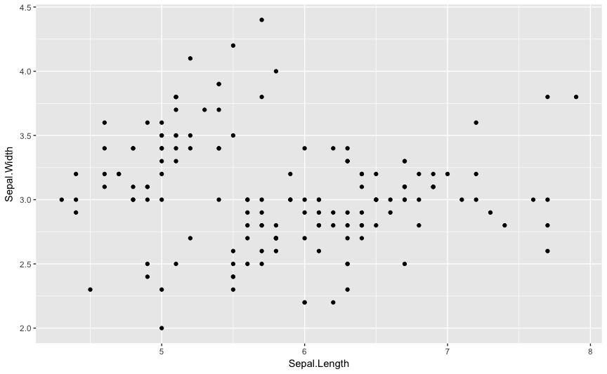

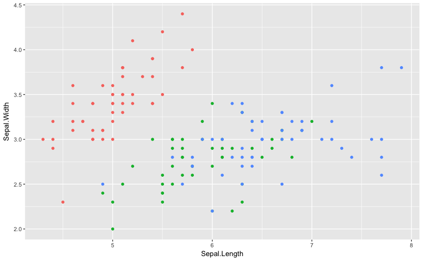

```r
ggplot(iris,aes(Sepal.Length,Sepal.Width))+geom_point()
ggplot(iris,aes(Sepal.Length,Sepal.Width,colour=Species))+ geom_point()+guides(colour=FALSE)
```

### Two plots

You can insert two parallel plots with the following code.

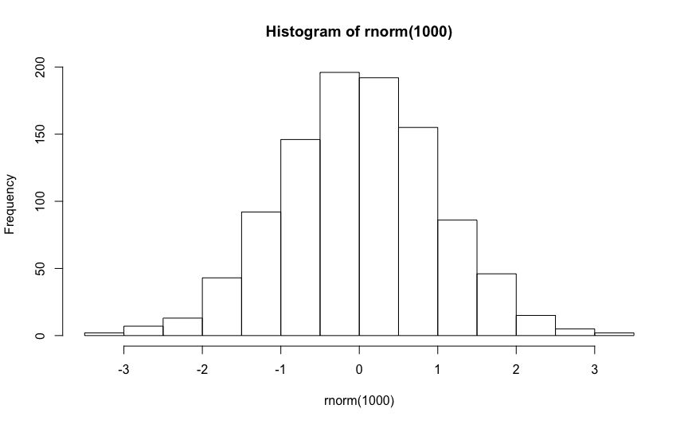

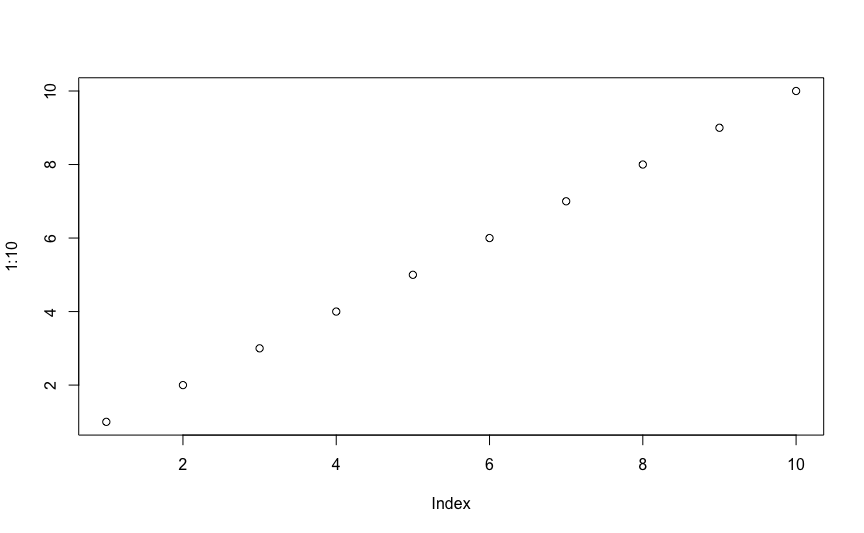

```r
hist(rnorm(1000))
plot(1:10)
```

### HTML Report

You can get report with HTML format(this file) by following R command.

```r
data2HTML(sampleData3)
```

### MS word document

You can get a report with MS word format.

```r
data2docx(sampleData3)
```

You can download sample data: sampleData3.docx - view with [office web viewer](https://view.officeapps.live.com/op/view.aspx?src=https://github.com/cardiomoon/rrtable/raw/master/inst/doc/sampleData3.docx)

```r
data2docx(sampleData2)
```

You can download sample data: sampleData2.docx - view with [office web viewer](https://view.officeapps.live.com/op/view.aspx?src=https://github.com/cardiomoon/rrtable/raw/master/inst/doc/sampleData2.docx)

### MS powerpoint document

```r
data2pptx(sampleData3)
```

You can download sample data: sampleData3.pptx - view with [office web viewer](https://view.officeapps.live.com/op/view.aspx?src=https://github.com/cardiomoon/rrtable/raw/master/inst/doc/sampleData3.pptx)

```r
data2pptx(sampleData2)
```

You can download sample data: sampleData2.pptx - view with [office web viewer](https://view.officeapps.live.com/op/view.aspx?src=https://github.com/cardiomoon/rrtable/raw/master/inst/doc/sampleData2.pptx)

### pdf document

You can get a report with pdf format.

```r
data2pdf(sampleData3)
```

You can download sample data: sampleData3.pdf

```r
data2pdf(sampleData2)
```

You can download sample data: sampleData2.pdf